© Bản quyền thuộc về Quantopian Inc.  
© Bản quyền sửa đổi thuộc về AI Cafe¹  
Giấy phép [Creative Commons Attribution 4.0](https://creativecommons.org/licenses/by/4.0/legalcode).  
[Khuyến cáo](https://aicafe.one/khuyen-cao/)

# Phân tích danh mục

by Samuel Ching, Maxwell Margenot, Gus Gordon, and Delaney Mackenzie

Edited by AI Cafe¹

Trong quy trình làm việc chuyên nghiệp của các nhà định lượng, việc chứng minh hiệu quả của bất kỳ danh mục đầu tư nào thông qua việc kiểm tra chặt chẽ là rất quan trọng. Điều này là cơ sở để hiểu rõ về hồ sơ rủi ro cũng như hiệu suất của danh mục đầu tư.

## Vấn đề với Backtesting

Thường thì có xu hướng chạy nhiều backtest trong quá trình xây dựng một thuật toán. Một cạm bẫy phổ biến là sử dụng thành công của các backtest như một tiêu chí phản hồi để tinh chỉnh các tham số hoặc đặc điểm của thuật toán trong khi vẫn đang ở giai đoạn xây dựng. Điều này dẫn đến việc quá khớp chiến lược với các thời kỳ mà người dùng đã thực hiện các backtest. Cuối cùng, điều này dẫn đến hiệu suất kém khi triển khai ra ngoài mẫu trong giao dịch trực tiếp.

Do đó, việc chạy các backtest và tạo ra các tearsheet chỉ nên xảy ra ở giai đoạn cuối của vòng đời tạo ra thuật toán. Chúng ta sẽ có được bức tranh về hiệu suất của thuật toán, giúp người dùng quyết định xem có nên tiếp tục triển khai thuật toán hay chuyển sang một chiến lược khác.

Có hai phần chính trong một tearsheet pyfolio đầy đủ. Đầu tiên, có các thống kê hiệu suất ở định dạng bảng. Các chỉ số hữu ích như tỷ suất sinh lợi hàng năm, beta thị trường và tỷ lệ Sharpe đều được liệt kê trong bảng này. Những chỉ số này không chỉ đại diện cho việc chiến lược đã hoạt động tốt như thế nào trong thời gian của backtest (tỷ lệ sinh lợi hàng năm), mà còn cho thấy tỷ suất sinh lợi điều chỉnh theo rủi ro được đo bằng các tỷ lệ khác nhau. Chúng ta sẽ đi vào chi tiết hơn về ý nghĩa của những chỉ số này.

Tiếp theo, có các biểu đồ giúp hình dung nhiều loại chỉ số hiệu suất. Ví dụ, người dùng có thể sử dụng các biểu đồ giảm giá để nhanh chóng xác định các thời kỳ mà chiến lược hoạt động kém nhất. Ngoài ra, nó sẽ giúp người dùng thấy liệu chiến lược có hoạt động như mong đợi hay không - nếu một chiến lược không bị ảnh hưởng bởi thị trường nhưng lại gặp phải các đợt giảm giá lớn trong các giai đoạn khủng hoảng, thì rõ ràng có vấn đề với thiết kế hoặc triển khai của chiến lược đó.

```python
!pip install -q pyfolio-reloaded empyrical-reloaded zipline-reloaded
```

```python
import pyfolio as pf
import matplotlib.pyplot as plt
import empyrical

import warnings
warnings.filterwarnings("ignore")
```

## Cài đặt danh mục để phân tích

Giả sử chúng ta xây dựng một danh mục cổ phiếu bao gồm FPT, HPG, VCB theo phương pháp chia đều vốn và chọn VNINDEX làm benchmark

```python
# Cài thư viện lấy dữ liệu miễn phí
!curl -fsSLO https://raw.githubusercontent.com/algo-stocks/data/master/data.py
```

```python
from data import get_prices

start = '2024-01-01'
end = '2025-01-01'

closes = get_prices('FPT', 'HPG', 'VCB', 'VNINDEX', start_date=start, end_date=end)

benchmark_rets = closes['VNINDEX'].ffill().pct_change().dropna()
bt_returns = closes.drop('VNINDEX', axis=1).pct_change().mean(axis=1).dropna()
```

Bây giờ, chúng ta đã sẵn sàng sử dụng pyfolio để khám phá các chỉ số hiệu suất và đồ thị khác nhau của thuật toán của chúng ta. Trong suốt bài giảng này, chúng ta sẽ chi tiết cách diễn giải các đồ thị riêng khác nhau được tạo ra bởi pyfolio và bao gồm lệnh thích hợp để tạo toàn bộ báo cáo.

## Thống kê Hiệu suất

Với pyfolio, có rất nhiều thống kê hiệu suất mà hầu hết các nhà quản lý quỹ chuyên nghiệp sẽ sử dụng để phân tích hiệu suất của thuật toán. Các chỉ số này bao gồm lợi nhuận hàng năm và hàng tháng của thuật toán, các phân vị lợi nhuận, beta cuộn và tỷ lệ Sharpe đến doanh thu của danh mục đầu tư. Các chỉ số quan trọng nhất sẽ được thảo luận như sau.

### Lợi nhuận điều chỉnh theo rủi ro

Lợi nhuận điều chỉnh theo rủi ro là một chỉ số quan trọng của bất kỳ chiến lược nào. Lợi nhuận điều chỉnh theo rủi ro cho phép chúng ta đánh giá các dòng lợi nhuận có độ biến động riêng lẻ khác nhau bằng cách cung cấp một phương tiện để so sánh có ý nghĩa. Có nhiều cách đo lường lợi nhuận điều chỉnh theo rủi ro, nhưng một trong những chỉ số phổ biến nhất là tỷ lệ Sharpe.

```python
print("The Sharpe Ratio of the backtest is: ", empyrical.sharpe_ratio(bt_returns))
```

```
The Sharpe Ratio of the backtest is:  1.865096570100442
```

### Beta Thị Trường

Beta thị trường của một thuật toán là mức độ tiếp xúc của chiến lược đó với thị trường rộng lớn hơn. Ví dụ, beta thị trường bằng $1$ có nghĩa là bạn đang mua vào thị trường, trong khi beta bằng $-1$ có nghĩa là bạn đang bán khống thị trường. Bất kỳ beta nào trong khoảng này cho thấy ảnh hưởng của thị trường được giảm bớt, trong khi bất kỳ beta nào ngoài khoảng này cho thấy ảnh hưởng của thị trường được tăng cường.

```python
print("The market beta of the backtest is: ", empyrical.beta(bt_returns,benchmark_rets))
```

```
The market beta of the backtest is:  0.9207793387536886
```

### Drawdowns

Drawdowns là sự 'sụt giảm từ đỉnh đến đáy' của một chiến lược đầu tư. Nói một cách trực quan, nó đề cập đến những tổn thất mà chiến lược đã trải qua từ số vốn cơ bản mà nó có ở đỉnh. Ví dụ, trong cuộc Khủng hoảng Tài chính 2008, mức giảm sút của thị trường là hơn 50% từ đỉnh năm 2007 đến đáy năm 2009.

```python
print("The maxmimum drawdown of the backtest is: ", empyrical.max_drawdown(bt_returns))
```

```
The maxmimum drawdown of the backtest is:  -0.08591775202527228
```

Đây là một thước đo khác về rủi ro tài chính của một thuật toán. Nếu mức giảm ròng của một chiến lược là rất đáng kể, điều này thường có nghĩa là độ biến động của thuật toán đó cũng lớn hơn. Các chiến lược tốt cố gắng hạn chế mức giảm. Một tiêu chuẩn tốt là có mức giảm tối đa dưới 20%.

## Plotting

Trong pyfolio, có một module `plotting` cho phép người dùng nhanh chóng vẽ các chỉ số này.

### Biểu đồ Lợi nhuận

Các biểu đồ về lợi nhuận tích lũy và lợi nhuận hàng ngày không tích lũy giúp bạn có cái nhìn nhanh chóng về hiệu suất của thuật toán và phát hiện bất kỳ sự bất thường nào trong khoảng thời gian backtest. Biểu đồ lợi nhuận tích lũy cũng cho phép bạn so sánh với lợi nhuận tham chiếu - điều này có thể so sánh với một chiến lược đầu tư khác hoặc một chỉ số như VNINDEX.

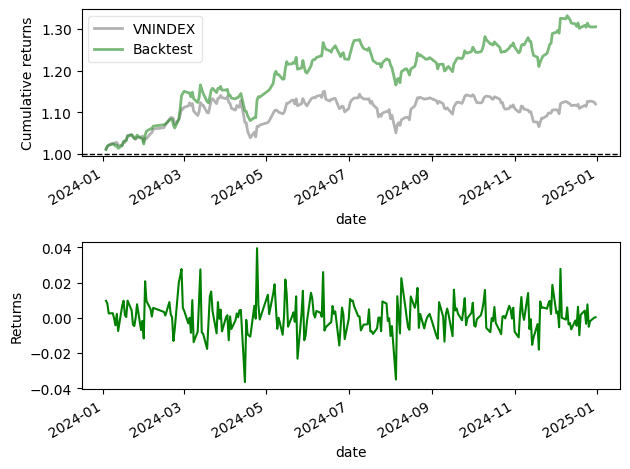

```python
# Cumulative Returns
plt.subplot(2,1,1)
pf.plotting.plot_rolling_returns(bt_returns, benchmark_rets)

# Daily, Non-Cumulative Returns
plt.subplot(2,1,2)
pf.plotting.plot_returns(bt_returns)
plt.tight_layout()
```

Với các biểu đồ lợi nhuận hàng năm và hàng tháng, bạn có thể thấy những năm và tháng mà thuật toán hoạt động tốt nhất. Ví dụ, trong biểu đồ nhiệt độ hàng tháng, thuật toán này đã hoạt động tốt nhất vào tháng 2 năm 2024 (được tô màu xanh đậm). Trong một bài backtest với khoảng thời gian dài hơn, các biểu đồ này sẽ tiết lộ nhiều thông tin hơn. Hơn nữa, sự phân bố của lợi nhuận hàng tháng cũng rất hữu ích trong việc đánh giá cách mà thuật toán hoạt động trong các giai đoạn khác nhau trong năm và xem nó có bị ảnh hưởng bởi các khuôn mẫu mùa vụ hay không.

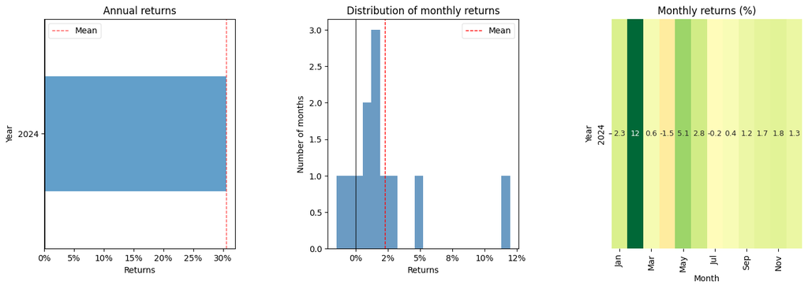

```python
fig = plt.figure(1)
plt.subplot(1,3,1)
pf.plot_annual_returns(bt_returns)
plt.subplot(1,3,2)
pf.plot_monthly_returns_dist(bt_returns)
plt.subplot(1,3,3)
pf.plot_monthly_returns_heatmap(bt_returns)
plt.tight_layout()
fig.set_size_inches(15,5)
```

#### Các Tứ Phân Lợi Nhuận

Các biểu đồ hộp và râu này cung cấp cái nhìn tổng quan về các tứ phân lợi nhuận được phân chia theo khung thời gian lợi nhuận (hàng ngày / hàng tuần / hàng tháng) trong toàn bộ khoảng thời gian backtest.

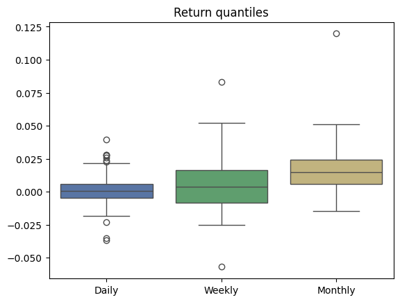

```python
pf.plot_return_quantiles(bt_returns);
```

Đường trung tâm ở giữa mỗi hộp cho thấy lợi nhuận trung vị, và hộp cho thấy tứ phân thứ nhất (percentile 25) cũng như tứ phân thứ ba (percentile 75). Trong khi lợi nhuận trung vị cao luôn hữu ích, việc hiểu rõ phân phối lợi nhuận cũng quan trọng không kém. Một hộp chặt chẽ có nghĩa là phần lớn lợi nhuận (từ percentile 25 đến 75) nằm trong một giới hạn hẹp - tức là lợi nhuận ổn định và không biến động lớn. Một hộp lớn hơn có nghĩa là lợi nhuận phân tán hơn. Tuy nhiên, điều quan trọng là phải chú ý đến thang đo bên trái để đặt các tứ phân vào đúng bối cảnh. Ngoài ra, lợi nhuận trong các khoảng thời gian dài hơn sẽ có phân phối rộng hơn vì việc tăng độ dài thời gian làm tăng tính biến động của lợi nhuận.

"Các sợi tua" ở cuối chỉ ra những lợi nhuận nằm ngoài percentile 25 và 75. Một hộp chặt chẽ với các sợi tua dài cho thấy có thể có những giá trị ngoại lai trong lợi nhuận - điều này có thể không lý tưởng nếu các giá trị ngoại lai đó là tiêu cực. Điều này có thể cho thấy chiến lược của bạn có thể nhạy cảm với một số điều kiện thị trường / khoảng thời gian nhất định.

### Biểu Đồ Động

Dưới đây, chúng ta có một số biểu đồ động cho thấy cách ước tính thay đổi trong suốt thời gian kiểm tra lại. Trong trường hợp của beta động và tỷ lệ Sharpe động, ước tính động cung cấp cho chúng ta nhiều thông tin hơn so với ước tính điểm đơn trong toàn bộ thời gian. Một ước tính động cho phép người dùng thấy liệu lợi nhuận điều chỉnh theo rủi ro của thuật toán (tỷ lệ Sharpe) có ổn định theo thời gian hay không, hoặc liệu nó có dao động đáng kể không. Một tỷ lệ Sharpe biến động có thể cho thấy rằng chiến lược có thể rủi ro hơn vào những thời điểm nhất định hoặc rằng nó không hoạt động tốt vào những thời điểm này. Tương tự, một beta biến động cho thấy rằng nó chịu ảnh hưởng từ thị trường vào những thời điểm nhất định - nếu chiến lược được thiết kế để trung lập với thị trường, điều này có thể là một dấu hiệu cảnh báo.

#### Biểu đồ Beta Động

Biểu đồ dưới đây cho thấy beta động của chiến lược so với lợi nhuận chuẩn trong toàn bộ thời gian của bài thử nghiệm. Trong trường hợp này, lợi nhuận chuẩn của VNINDEX đã được sử dụng. Vì vậy, beta danh mục động càng thấp so với VNINDEX, thuật toán càng trung tính với thị trường.

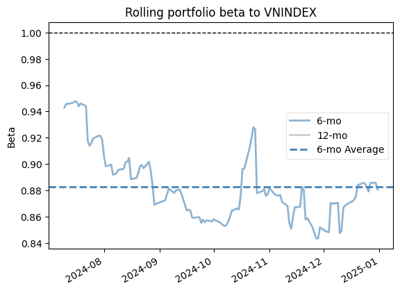

```python
pf.plot_rolling_beta(bt_returns, benchmark_rets);
```

#### Biểu đồ Tỷ lệ Sharpe Động

Biểu đồ dưới đây cho thấy tỷ lệ Sharpe động trong khoảng thời gian backtest. Điều này giúp bạn hiểu được hiệu suất của thuật toán tại các thời điểm khác nhau.

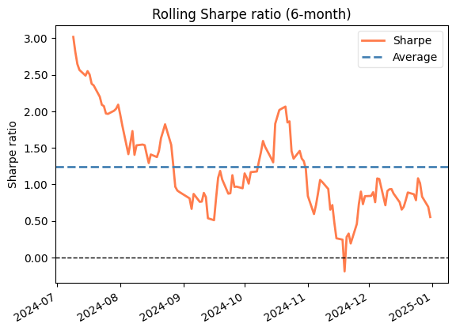

```python
pf.plot_rolling_sharpe(bt_returns);
```

#### Biểu Đồ Giảm Giá

Trong biểu đồ này, chúng ta sẽ trực quan hóa biểu đồ giảm giá đã được mô tả ở trên. Biểu đồ này cung cấp cái nhìn tổng quan về các khoảng thời gian giảm giá tồi tệ nhất trong quá trình backtest. Những khoảng thời gian này cho thấy các khung thời gian trong quá trình kiểm tra lại mà 10 khoảng giảm giá lớn nhất đã xảy ra.

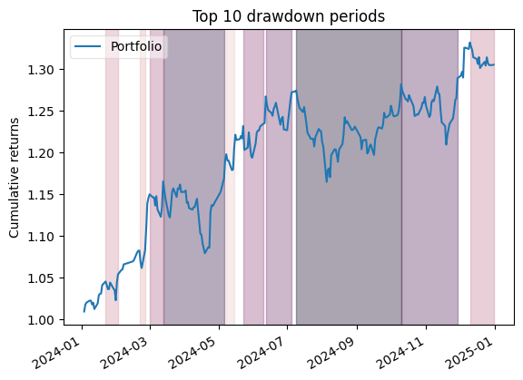

```python
pf.plot_drawdown_periods(bt_returns);
```

Điều này, kết hợp với biểu đồ underwater, cho phép kiểm tra nhanh vào các thời kỳ mà thuật toán gặp khó khăn. Nói chung, càng ít biến động thì thuật toán càng có xu hướng giảm thiểu được các đợt giảm giá.

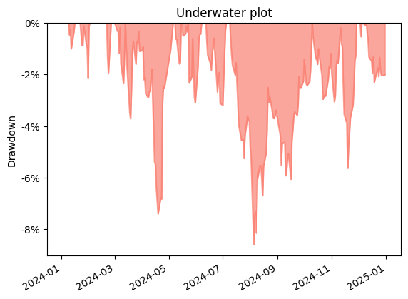

```python
pf.plot_drawdown_underwater(bt_returns);
```

## Tạo bản báo cáo tổng hợp

| Start date End date Total months | 2024-01-03 2024-12-31 11 Backtest | 2024-01-03 2024-12-31 11 |
| --- | --- | --- |
| Annual return | 30.95% |  |
| Cumulative returns | 30.531% |  |
| Annual volatility | 15.071% |  |
| Sharpe ratio | 1.87 |  |
| Calmar ratio | 3.60 |  |
| Stability | 0.77 |  |
| Max drawdown | -8.592% |  |
| Omega ratio | 1.38 |  |
| Sortino ratio | 2.98 |  |
| Skew | 0.16 |  |
| Kurtosis | 2.43 |  |
| Tail ratio | 1.37 |  |
| Daily value at risk | -1.787% |  |
| Alpha | 0.18 |  |
| Beta | 0.92 |  |

| Worst drawdown periods | Net drawdown in % | Peak date | Valley date | Recovery date | Duration |
| --- | --- | --- | --- | --- | --- |
| 0 | 8.59 | 2024-07-09 | 2024-08-05 | 2024-10-10 | 68 |
| 1 | 7.39 | 2024-03-13 | 2024-04-19 | 2024-05-06 | 39 |
| 2 | 5.63 | 2024-10-10 | 2024-11-19 | 2024-11-29 | 37 |
| 3 | 3.19 | 2024-06-12 | 2024-07-01 | 2024-07-05 | 18 |
| 4 | 3.09 | 2024-05-23 | 2024-05-31 | 2024-06-10 | 13 |

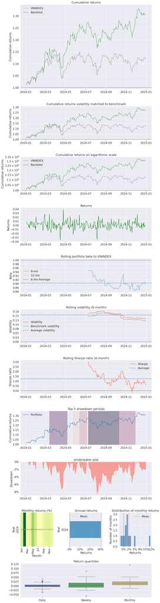

```python
pf.create_full_tear_sheet(bt_returns, benchmark_rets=benchmark_rets)
```

*Lưu ý: Tài liệu này mang tính chất chia sẻ kiến thức khoa học dữ liệu. Các mã chứng khoán xuất hiện trong tài liệu chỉ mang tính chất minh hoạ, không khuyến nghị đầu tư. Chúng tôi không chịu trách nhiệm trước mọi rủi ro nào do sử dụng tài liệu này.*